### Importing required libraries

```python
import pandas as pd
from statsmodels.tsa.arima.model import ARIMA
import matplotlib.pyplot as plt
import warnings
from statsmodels.graphics.tsaplots import plot_acf, plot_pacf
import statsmodels.api as sm
from sklearn.metrics import mean_squared_error

warnings.filterwarnings("ignore")

plt.rcParams["figure.figsize"] = (10,5)
```

# Question 1

The data provided in the file Measurement_Q1.xls exhibits a linear trend. Apply the following models to the data. (20 pts)

```python
df = pd.read_csv('Measurement_Q1.csv', index_col = 'Time')
df
```

| Time | Measurement |
| --- | --- |
| 1 | 1.84 |
| 2 | 3.93 |
| 3 | 4.00 |
| 4 | 5.42 |
| 5 | 6.89 |
| ... | ... |
| 146 | 3.65 |
| 147 | 2.82 |
| 148 | 2.81 |
| 149 | 1.64 |
| 150 | 0.00 |

150 rows × 1 columns

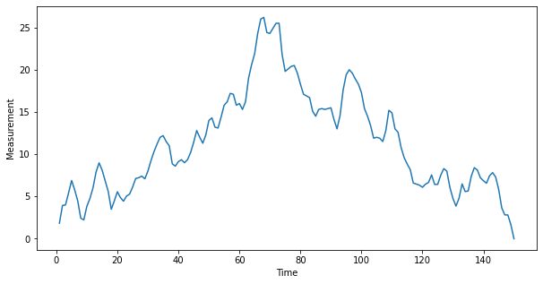

```python
plt.xlabel('Time')
plt.ylabel('Measurement')
plt.plot(df)
plt.show()
```

## Part a

Develop an IMA(1,1) model for the data. Display the model parameters obtained as your output (8 pts)

```python
model = ARIMA(df.Measurement, order=(0,1,1))
model_fit = model.fit()
model_fit.summary()
```

SARIMAX Results

| Dep. Variable: | Measurement | No. Observations: | 150 |
| --- | --- | --- | --- |
| Model: | ARIMA(0, 1, 1) | Log Likelihood | -202.609 |
| Date: | Wed, 12 Oct 2022 | AIC | 409.217 |
| Time: | 12:36:16 | BIC | 415.225 |
| Sample: | 0 | HQIC | 411.658 |
|  | - 150 |  |  |
| Covariance Type: | opg |  |  |

|  | coef | std err | z | P>\|z\| | [0.025 | 0.975] |
| --- | --- | --- | --- | --- | --- | --- |
| ma.L1 | 0.7531 | 0.060 | 12.573 | 0.000 | 0.636 | 0.871 |
| sigma2 | 0.8834 | 0.109 | 8.080 | 0.000 | 0.669 | 1.098 |

| Ljung-Box (L1) (Q): | 0.26 | Jarque-Bera (JB): | 1.10 |
| --- | --- | --- | --- |
| Prob(Q): | 0.61 | Prob(JB): | 0.58 |
| Heteroskedasticity (H): | 1.00 | Skew: | -0.21 |
| Prob(H) (two-sided): | 0.99 | Kurtosis: | 2.98 |

Warnings:  
[1] Covariance matrix calculated using the outer product of gradients (complex-step).

## Part b

Compute and plot the first difference of the data. (2 pts)

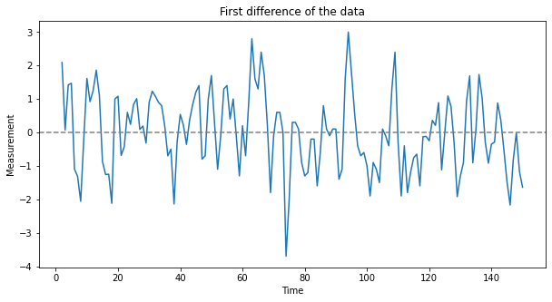

```python
df_diff1 = sm.tsa.statespace.tools.diff(df.Measurement, k_diff=1)
plt.plot (df_diff1)
plt.axhline(y=0, color='grey', linestyle='--')
plt.xlabel ('Time')
plt.ylabel ('Measurement')
plt.title ('First difference of the data')
plt.show()
```

## Part c

Now, develop an MA(1) model on the first difference. Display the model parameters obtained as your output (8 pts)

```python
model = ARIMA(df_diff1, order=(0,0,1))
model_fit = model.fit()
model_fit.summary()
```

SARIMAX Results

| Dep. Variable: | Measurement | No. Observations: | 149 |
| --- | --- | --- | --- |
| Model: | ARIMA(0, 0, 1) | Log Likelihood | -202.607 |
| Date: | Wed, 12 Oct 2022 | AIC | 411.215 |
| Time: | 12:38:58 | BIC | 420.227 |
| Sample: | 0 | HQIC | 414.876 |
|  | - 149 |  |  |
| Covariance Type: | opg |  |  |

|  | coef | std err | z | P>\|z\| | [0.025 | 0.975] |
| --- | --- | --- | --- | --- | --- | --- |
| const | -0.0064 | 0.137 | -0.047 | 0.962 | -0.274 | 0.261 |
| ma.L1 | 0.7531 | 0.061 | 12.392 | 0.000 | 0.634 | 0.872 |
| sigma2 | 0.8834 | 0.110 | 8.052 | 0.000 | 0.668 | 1.098 |

| Ljung-Box (L1) (Q): | 0.26 | Jarque-Bera (JB): | 1.10 |
| --- | --- | --- | --- |
| Prob(Q): | 0.61 | Prob(JB): | 0.58 |
| Heteroskedasticity (H): | 0.99 | Skew: | -0.21 |
| Prob(H) (two-sided): | 0.98 | Kurtosis: | 2.98 |

Warnings:  
[1] Covariance matrix calculated using the outer product of gradients (complex-step).

## Part d

Based on the model parameters you obtained in (a) and (c), comment on how the two models are related. (2 pts)

This is because IMA(1,1) has d = 1 and q = 1. This just means that the first difference is calculated automatically and it includes a 1 MA term.

for the second model the differencig is performed manually hence d = 1 and there is also n MA 1 term included so d = 1 amd q = 1 even with the second model.

# Question 2

Consider the global mean surface air temperature anomaly data provided in GlobalAirTemperature.xls. (15 pts)

```python
df = pd.read_csv('GlobalAirTemperature.csv', index_col = 'Year')
df
```

| Year | Anomaly, C |
| --- | --- |
| 1880 | -0.11 |
| 1881 | -0.13 |
| 1882 | -0.01 |
| 1883 | -0.04 |
| 1884 | -0.42 |
| ... | ... |
| 2000 | 0.41 |
| 2001 | 0.56 |
| 2002 | 0.70 |
| 2003 | 0.66 |
| 2004 | 0.60 |

125 rows × 1 columns

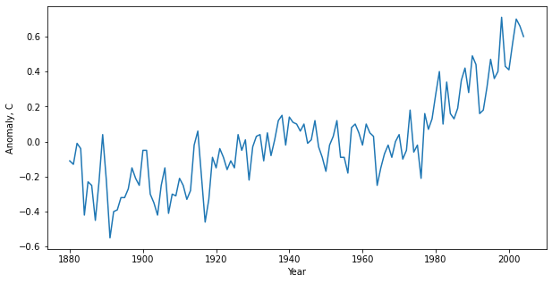

```python
plt.xlabel('Year')
plt.ylabel('Anomaly, C')
plt.plot(df)
plt.show()
```

## Part a

Apply an IMA(1,1) model to this data. Calculate the SSE by comparing the model output with the data. (6 pts)

```python
model = ARIMA(df['Anomaly, C'], order=(0,1,1))
model_fit = model.fit()
model_fit.summary()
```

SARIMAX Results

| Dep. Variable: | Anomaly, C | No. Observations: | 125 |
| --- | --- | --- | --- |
| Model: | ARIMA(0, 1, 1) | Log Likelihood | 72.910 |
| Date: | Wed, 12 Oct 2022 | AIC | -141.821 |
| Time: | 12:51:14 | BIC | -136.180 |
| Sample: | 0 | HQIC | -139.530 |
|  | - 125 |  |  |
| Covariance Type: | opg |  |  |

|  | coef | std err | z | P>\|z\| | [0.025 | 0.975] |
| --- | --- | --- | --- | --- | --- | --- |
| ma.L1 | -0.6640 | 0.072 | -9.243 | 0.000 | -0.805 | -0.523 |
| sigma2 | 0.0180 | 0.002 | 8.182 | 0.000 | 0.014 | 0.022 |

| Ljung-Box (L1) (Q): | 2.36 | Jarque-Bera (JB): | 2.20 |
| --- | --- | --- | --- |
| Prob(Q): | 0.12 | Prob(JB): | 0.33 |
| Heteroskedasticity (H): | 0.87 | Skew: | -0.29 |
| Prob(H) (two-sided): | 0.65 | Kurtosis: | 3.32 |

Warnings:  
[1] Covariance matrix calculated using the outer product of gradients (complex-step).

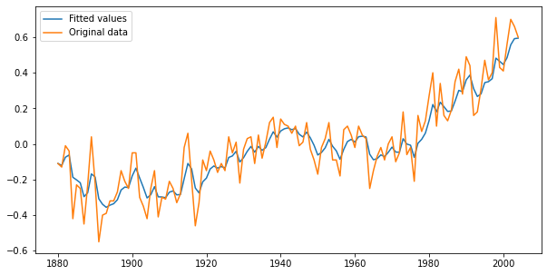

```python
df_pred = model_fit.predict(start=1,end=len(df['Anomaly, C']), typ = 'levels').rename("Predictions")
plt.plot (df.index, df_pred, label='Fitted values')
plt.plot (df.index, df['Anomaly, C'], label='Original data')
plt.legend()
plt.show()
```

```python
sse = mean_squared_error (df['Anomaly, C'].values, df_pred.values) * len(df_pred)
sse,len(df_pred.values)
```

```
(0.9811083887548632, 125)
```

## Part b

Now, apply an IMA(1,2) model. Calculate the SSE. (6 pts)

```python
model = ARIMA(df['Anomaly, C'], order=(0,1,2))
model_fit = model.fit()
model_fit.summary()
```

SARIMAX Results

| Dep. Variable: | Anomaly, C | No. Observations: | 125 |
| --- | --- | --- | --- |
| Model: | ARIMA(0, 1, 2) | Log Likelihood | 76.508 |
| Date: | Wed, 12 Oct 2022 | AIC | -147.016 |
| Time: | 12:58:43 | BIC | -138.555 |
| Sample: | 0 | HQIC | -143.579 |
|  | - 125 |  |  |
| Covariance Type: | opg |  |  |

|  | coef | std err | z | P>\|z\| | [0.025 | 0.975] |
| --- | --- | --- | --- | --- | --- | --- |
| ma.L1 | -0.4676 | 0.099 | -4.736 | 0.000 | -0.661 | -0.274 |
| ma.L2 | -0.2296 | 0.090 | -2.565 | 0.010 | -0.405 | -0.054 |
| sigma2 | 0.0170 | 0.002 | 7.631 | 0.000 | 0.013 | 0.021 |

| Ljung-Box (L1) (Q): | 0.13 | Jarque-Bera (JB): | 1.18 |
| --- | --- | --- | --- |
| Prob(Q): | 0.72 | Prob(JB): | 0.55 |
| Heteroskedasticity (H): | 1.04 | Skew: | -0.23 |
| Prob(H) (two-sided): | 0.91 | Kurtosis: | 3.12 |

Warnings:  
[1] Covariance matrix calculated using the outer product of gradients (complex-step).

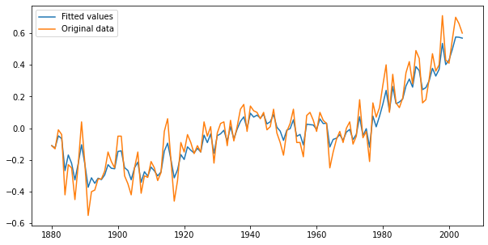

```python
df_pred = model_fit.predict(start=1,end=len(df['Anomaly, C']), typ = 'levels').rename("Predictions")
plt.plot (df.index, df_pred, label='Fitted values')
plt.plot (df.index, df['Anomaly, C'], label='Original data')
plt.legend()
plt.show()
```

```python
sse = mean_squared_error (df['Anomaly, C'].values, df_pred.values) * len(df_pred)
sse,len(df_pred.values)
```

```
(0.5617319358156067, 125)
```

## Part c

Comment whether model (a) or (b) is better suited for this data based on the SSE? (3 pts)

# Question 3

Review the dataset in the file Measurement_Q3.xls which contains measurements recorded annually over close to 50 years. (15 pts)

```python
df = pd.read_csv('Measurement_Q3.csv', index_col = 'Year')
df
```

| Year | Measurement |
| --- | --- |
| 1950 | 2.429415 |
| 1951 | 2.363364 |
| 1952 | 2.374305 |
| 1953 | 2.295520 |
| 1954 | 2.329716 |
| 1955 | 2.233017 |
| 1956 | 2.378179 |
| 1957 | 2.322671 |
| 1958 | 2.416556 |
| 1959 | 2.498199 |
| 1960 | 2.579453 |
| 1961 | 2.580840 |
| 1962 | 2.629293 |
| 1963 | 2.581853 |
| 1964 | 2.720940 |
| 1965 | 2.844774 |
| 1966 | 3.144862 |
| 1967 | 3.433044 |
| 1968 | 3.358418 |
| 1969 | 3.462620 |
| 1970 | 3.647342 |
| 1971 | 3.991080 |
| 1972 | 3.925702 |
| 1973 | 4.490962 |
| 1974 | 4.491541 |
| 1975 | 4.396567 |
| 1976 | 3.984491 |
| 1977 | 4.115111 |
| 1978 | 4.018538 |
| 1979 | 4.201107 |
| 1980 | 4.367459 |
| 1981 | 4.228103 |
| 1982 | 4.145889 |
| 1983 | 3.786691 |
| 1984 | 3.827373 |
| 1985 | 3.820376 |
| 1986 | 4.025134 |
| 1987 | 4.070130 |
| 1988 | 4.105920 |
| 1989 | 4.039027 |
| 1990 | 4.113978 |
| 1991 | 4.410670 |
| 1992 | 4.110586 |
| 1993 | 4.357700 |
| 1994 | 3.959040 |
| 1995 | 3.882907 |
| 1996 | 3.524803 |
| 1997 | 3.249564 |
| 1998 | 3.139884 |
| 1999 | 3.034263 |
| 2000 | 2.805041 |
| 2001 | 3.304467 |
| 2002 | 2.797697 |
| 2003 | 2.662227 |
| 2004 | 2.589383 |

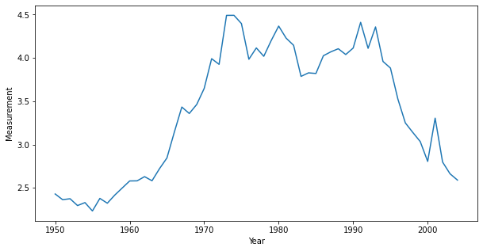

```python
plt.xlabel('Year')
plt.ylabel('Measurement')
plt.plot(df)
plt.show()
```

## Part a

Plot the time series, ACF, and Partial AutoCorrelation Function (PACF). (6 pts)

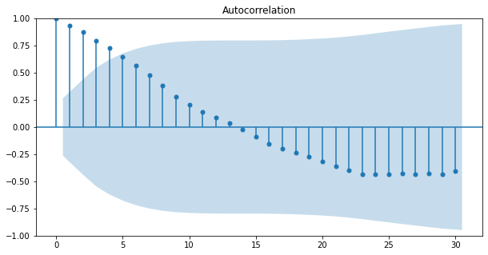

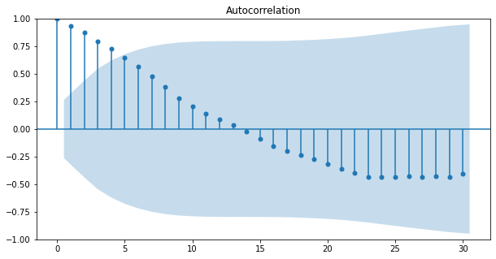

```python
plot_acf(df.Measurement, lags = 30)
```

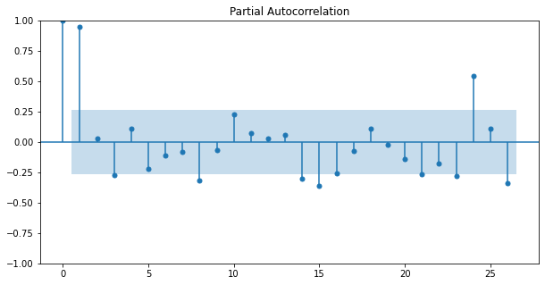

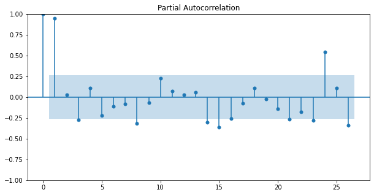

```python
plot_pacf(df.Measurement, lags = 26)
```

## Part b

Compute the first difference and plot its ACF and PACF. (6 pts)

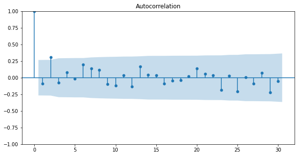

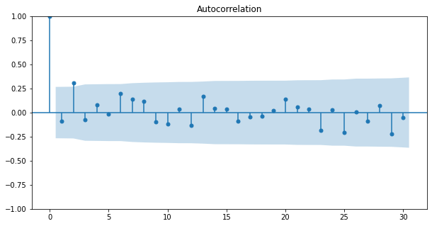

```python
plot_acf(df.diff().dropna(), lags = 30)
```

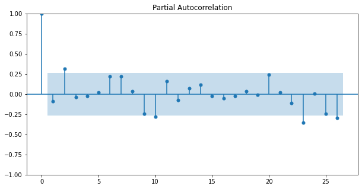

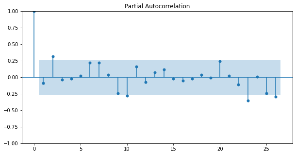

```python
plot_pacf(df.diff().dropna(), lags = 26)
```

## Part c

Based on the results in (b) above, what model order, i.e. p,d,q in ARMA(p,d,q), would you recommend for the above time series? Provide a justification for your answer. (3 pts)

According tp the plots above d should be equal to 1 and the values of p and q can be 0, 1 or 2. So, it might be worth fitting different combinations of these values to multiple ARIMA models and pick the one with the lowest AIC Score.

```python
# Arima(0,1,1)

arima = ARIMA(df.Measurement, order=(0,1,1))
arima_fit = arima.fit()
arima_fit.summary()
```

SARIMAX Results

| Dep. Variable: | Measurement | No. Observations: | 55 |
| --- | --- | --- | --- |
| Model: | ARIMA(0, 1, 1) | Log Likelihood | 6.850 |
| Date: | Thu, 13 Oct 2022 | AIC | -9.700 |
| Time: | 13:42:19 | BIC | -5.722 |
| Sample: | 0 | HQIC | -8.166 |
|  | - 55 |  |  |
| Covariance Type: | opg |  |  |

|  | coef | std err | z | P>\|z\| | [0.025 | 0.975] |
| --- | --- | --- | --- | --- | --- | --- |
| ma.L1 | -0.0527 | 0.130 | -0.404 | 0.686 | -0.308 | 0.203 |
| sigma2 | 0.0454 | 0.009 | 5.320 | 0.000 | 0.029 | 0.062 |

| Ljung-Box (L1) (Q): | 0.02 | Jarque-Bera (JB): | 0.23 |
| --- | --- | --- | --- |
| Prob(Q): | 0.90 | Prob(JB): | 0.89 |
| Heteroskedasticity (H): | 4.05 | Skew: | 0.07 |
| Prob(H) (two-sided): | 0.00 | Kurtosis: | 3.29 |

Warnings:  
[1] Covariance matrix calculated using the outer product of gradients (complex-step).

```python
# Arima(0,1,2)

arima = ARIMA(df.Measurement, order=(0,1,2))
arima_fit = arima.fit()
arima_fit.summary()
```

SARIMAX Results

| Dep. Variable: | Measurement | No. Observations: | 55 |
| --- | --- | --- | --- |
| Model: | ARIMA(0, 1, 2) | Log Likelihood | 9.713 |
| Date: | Thu, 13 Oct 2022 | AIC | -13.425 |
| Time: | 13:41:57 | BIC | -7.458 |
| Sample: | 0 | HQIC | -11.124 |
|  | - 55 |  |  |
| Covariance Type: | opg |  |  |

|  | coef | std err | z | P>\|z\| | [0.025 | 0.975] |
| --- | --- | --- | --- | --- | --- | --- |
| ma.L1 | -0.0660 | 0.110 | -0.598 | 0.550 | -0.282 | 0.150 |
| ma.L2 | 0.3712 | 0.128 | 2.907 | 0.004 | 0.121 | 0.622 |
| sigma2 | 0.0406 | 0.008 | 4.999 | 0.000 | 0.025 | 0.057 |

| Ljung-Box (L1) (Q): | 0.00 | Jarque-Bera (JB): | 0.03 |
| --- | --- | --- | --- |
| Prob(Q): | 0.96 | Prob(JB): | 0.99 |
| Heteroskedasticity (H): | 4.20 | Skew: | -0.00 |
| Prob(H) (two-sided): | 0.00 | Kurtosis: | 2.89 |

Warnings:  
[1] Covariance matrix calculated using the outer product of gradients (complex-step).

```python
# Arima(1,1,0)

arima = ARIMA(df.Measurement, order=(1,1,0))
arima_fit = arima.fit()
arima_fit.summary()
```

SARIMAX Results

| Dep. Variable: | Measurement | No. Observations: | 55 |
| --- | --- | --- | --- |
| Model: | ARIMA(1, 1, 0) | Log Likelihood | 6.923 |
| Date: | Thu, 13 Oct 2022 | AIC | -9.846 |
| Time: | 13:41:38 | BIC | -5.868 |
| Sample: | 0 | HQIC | -8.312 |
|  | - 55 |  |  |
| Covariance Type: | opg |  |  |

|  | coef | std err | z | P>\|z\| | [0.025 | 0.975] |
| --- | --- | --- | --- | --- | --- | --- |
| ar.L1 | -0.0841 | 0.129 | -0.653 | 0.514 | -0.336 | 0.168 |
| sigma2 | 0.0453 | 0.009 | 5.238 | 0.000 | 0.028 | 0.062 |

| Ljung-Box (L1) (Q): | 0.03 | Jarque-Bera (JB): | 0.17 |
| --- | --- | --- | --- |
| Prob(Q): | 0.86 | Prob(JB): | 0.92 |
| Heteroskedasticity (H): | 3.92 | Skew: | 0.08 |
| Prob(H) (two-sided): | 0.01 | Kurtosis: | 3.23 |

Warnings:  
[1] Covariance matrix calculated using the outer product of gradients (complex-step).

```python
# Arima(2,1,0)

arima = ARIMA(df.Measurement, order=(2,1,0))
arima_fit = arima.fit()
arima_fit.summary()
```

SARIMAX Results

| Dep. Variable: | Measurement | No. Observations: | 55 |
| --- | --- | --- | --- |
| Model: | ARIMA(2, 1, 0) | Log Likelihood | 9.479 |
| Date: | Thu, 13 Oct 2022 | AIC | -12.959 |
| Time: | 13:42:37 | BIC | -6.992 |
| Sample: | 0 | HQIC | -10.657 |
|  | - 55 |  |  |
| Covariance Type: | opg |  |  |

|  | coef | std err | z | P>\|z\| | [0.025 | 0.975] |
| --- | --- | --- | --- | --- | --- | --- |
| ar.L1 | -0.0572 | 0.118 | -0.486 | 0.627 | -0.287 | 0.173 |
| ar.L2 | 0.2967 | 0.125 | 2.371 | 0.018 | 0.051 | 0.542 |
| sigma2 | 0.0411 | 0.008 | 4.965 | 0.000 | 0.025 | 0.057 |

| Ljung-Box (L1) (Q): | 0.00 | Jarque-Bera (JB): | 0.06 |
| --- | --- | --- | --- |
| Prob(Q): | 0.96 | Prob(JB): | 0.97 |
| Heteroskedasticity (H): | 4.24 | Skew: | 0.08 |
| Prob(H) (two-sided): | 0.00 | Kurtosis: | 2.96 |

Warnings:  
[1] Covariance matrix calculated using the outer product of gradients (complex-step).

```python
# Arima(1,1,1)

arima = ARIMA(df.Measurement, order=(1,1,1))
arima_fit = arima.fit()
arima_fit.summary()
```

SARIMAX Results

| Dep. Variable: | Measurement | No. Observations: | 55 |
| --- | --- | --- | --- |
| Model: | ARIMA(1, 1, 1) | Log Likelihood | 8.178 |
| Date: | Thu, 13 Oct 2022 | AIC | -10.357 |
| Time: | 13:43:17 | BIC | -4.390 |
| Sample: | 0 | HQIC | -8.056 |
|  | - 55 |  |  |
| Covariance Type: | opg |  |  |

|  | coef | std err | z | P>\|z\| | [0.025 | 0.975] |
| --- | --- | --- | --- | --- | --- | --- |
| ar.L1 | -0.8254 | 0.326 | -2.530 | 0.011 | -1.465 | -0.186 |
| ma.L1 | 0.6915 | 0.408 | 1.696 | 0.090 | -0.108 | 1.491 |
| sigma2 | 0.0432 | 0.009 | 4.977 | 0.000 | 0.026 | 0.060 |

| Ljung-Box (L1) (Q): | 0.66 | Jarque-Bera (JB): | 0.10 |
| --- | --- | --- | --- |
| Prob(Q): | 0.42 | Prob(JB): | 0.95 |
| Heteroskedasticity (H): | 3.81 | Skew: | 0.11 |
| Prob(H) (two-sided): | 0.01 | Kurtosis: | 2.98 |

Warnings:  
[1] Covariance matrix calculated using the outer product of gradients (complex-step).

```python
# Arima(2,1,2)

arima = ARIMA(df.Measurement, order=(2,1,2))
arima_fit = arima.fit()
arima_fit.summary()
```

SARIMAX Results

| Dep. Variable: | Measurement | No. Observations: | 55 |
| --- | --- | --- | --- |
| Model: | ARIMA(2, 1, 2) | Log Likelihood | 11.857 |
| Date: | Thu, 13 Oct 2022 | AIC | -13.714 |
| Time: | 13:43:35 | BIC | -3.769 |
| Sample: | 0 | HQIC | -9.879 |
|  | - 55 |  |  |
| Covariance Type: | opg |  |  |

|  | coef | std err | z | P>\|z\| | [0.025 | 0.975] |
| --- | --- | --- | --- | --- | --- | --- |
| ar.L1 | 0.3859 | 0.128 | 3.025 | 0.002 | 0.136 | 0.636 |
| ar.L2 | -0.5070 | 0.178 | -2.847 | 0.004 | -0.856 | -0.158 |
| ma.L1 | -0.4354 | 6.479 | -0.067 | 0.946 | -13.134 | 12.263 |
| ma.L2 | 0.9996 | 29.774 | 0.034 | 0.973 | -57.357 | 59.356 |
| sigma2 | 0.0347 | 1.030 | 0.034 | 0.973 | -1.985 | 2.054 |

| Ljung-Box (L1) (Q): | 0.23 | Jarque-Bera (JB): | 0.48 |
| --- | --- | --- | --- |
| Prob(Q): | 0.64 | Prob(JB): | 0.79 |
| Heteroskedasticity (H): | 4.36 | Skew: | -0.23 |
| Prob(H) (two-sided): | 0.00 | Kurtosis: | 3.09 |

Warnings:  
[1] Covariance matrix calculated using the outer product of gradients (complex-step).

The lollipop graph suggest p=2 and q=2 which is confirmed by the low AIC Score for ARIMA(2,1,2).